# Project EDA

Savannah Sauers, Lera Martinez, Simon Tao

2026-10-18

```r
# Make sure columns are cast to correct types
project$borough <- as.factor(project$borough)
project$payment_method <- as.factor(project$payment_method)
project$fare_class_category <- as.factor(project$fare_class_category)
project$ridership <- as.numeric(gsub(",", "", project$ridership))
project$transfers <- as.numeric(gsub(",", "", project$transfers))
```

# Proofing data

```r
# Checking for any NA values
colSums(is.na(project))
```

```
##   transit_timestamp        transit_mode  station_complex_id     station_complex
##                   0                   0                   0                   0
##             borough      payment_method fare_class_category           ridership
##                   0                   0                   0                   0
##           transfers            latitude           longitude        Georeference
##                   0                   0                   0                   0
```

```r
# Checking for duplicates
sum(duplicated(project))
```

```
## [1] 0
```

```r
str(project)
```

```
## 'data.frame':    553429 obs. of  12 variables:
##  $ transit_timestamp  : chr  "09/15/2024 12:00:00 AM" "09/15/2024 12:00:00 AM" "09/15/2024 12:00:00 AM" "09/15/2024 12:00:00 AM" ...
##  $ transit_mode       : chr  "subway" "subway" "subway" "subway" ...
##  $ station_complex_id : int  74 260 375 376 224 220 301 397 180 83 ...
##  $ station_complex    : chr  "18 Av (N)" "75 Av (E,F)" "Cypress Av (6)" "Brook Av (6)" ...
##  $ borough            : Factor w/ 4 levels "Bronx","Brooklyn",..: 2 4 1 1 3 3 3 3 2 4 ...
##  $ payment_method     : Factor w/ 2 levels "metrocard","omny": 2 2 2 2 2 1 2 1 1 1 ...
##  $ fare_class_category: Factor w/ 12 levels "Metrocard - Fair Fare",..: 12 9 9 9 12 6 9 6 1 2 ...
##  $ ridership          : num  1 6 4 1 6 1 20 25 3 6 ...
##  $ transfers          : num  0 0 0 0 0 0 0 0 0 0 ...
##  $ latitude           : num  40.6 40.7 40.8 40.8 40.8 ...
##  $ longitude          : num  -74 -73.8 -73.9 -73.9 -74 ...
##  $ Georeference       : chr  "POINT (-73.99042 40.62067)" "POINT (-73.837326 40.71833)" "POINT (-73.91404 40.805367)" "POINT (-73.91924 40.807568)" ...
```

```r
# Checking for any negative values to make sure there were no stragglers in the data cleaning
sum(project$ridership < 0, na.rm = TRUE)
```

```
## [1] 0
```

```r
sum(project$transfers < 0, na.rm = TRUE)
```

```
## [1] 0
```

```r
with_timestamp <- project %>%
  mutate(timestamp = mdy_hms(transit_timestamp))

observations_total <- with_timestamp %>%
  mutate(date = as.Date(timestamp)) %>%
  count(date, name = "number_of_observations") %>%
  arrange(date)

observations_total
```

```
##         date number_of_observations
## 1 2024-09-15                  72335
## 2 2024-09-16                  80108
## 3 2024-09-17                  80462
## 4 2024-09-18                  80688
## 5 2024-09-19                  81057
## 6 2024-09-20                  81407
## 7 2024-09-21                  77372
```

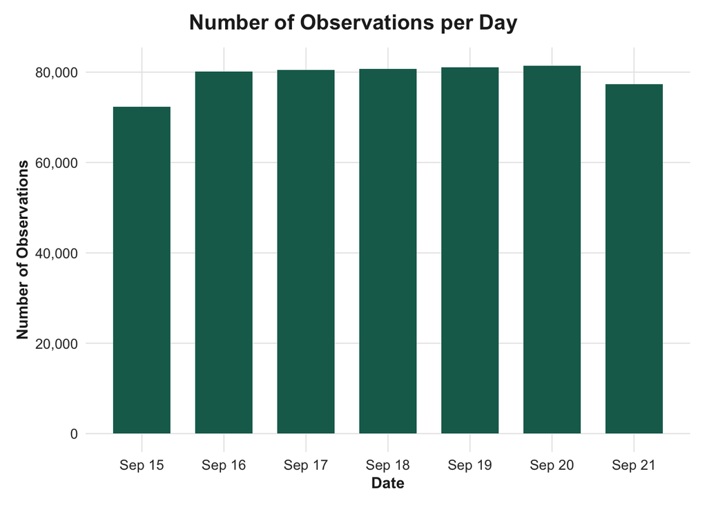

```r
week_bar_chart_observations <- ggplot(observations_total, aes(x = date, y = number_of_observations)) +
  geom_col(fill = "#176B5B", width = 0.7) +
  scale_x_date(breaks = observations_total$date,date_labels = "%b %d")+ #To include all the dates on the x axis with the month and date
  scale_y_continuous(labels = scales::comma) +
  labs(
    title = "Number of Observations per Day",
    x = "Date",
    y = "Number of Observations"
  ) +

  theme_mygraphs()


week_bar_chart_observations
```

# Descriptive Statistics

```r
xkablesummary (project, title = "Summary Statistics for Project")
```

Summary Statistics for Project

|  | transit_timestamp | transit_mode | station_complex_id | station_complex | borough | payment_method | fare_class_category | ridership | transfers | latitude | longitude | Georeference |
| --- | --- | --- | --- | --- | --- | --- | --- | --- | --- | --- | --- | --- |
| Min | Length :553429 | Length :553429 | Min. : 1.0 | Length :553429 | Bronx : 88162 | metrocard:371260 | OMNY - Full Fare : 68758 | Min. : 1.00 | Min. : 0.000 | Min. :40.58 | Min. :-74.03 | Length :553429 |
| Q1 | N.unique : 168 | N.unique : 1 | 1st Qu.:137.0 | N.unique : 424 | Brooklyn :196976 | omny :182169 | Metrocard - Full Fare : 65844 | 1st Qu.: 3.00 | 1st Qu.: 0.000 | 1st Qu.:40.68 | 1st Qu.:-73.98 | N.unique : 483 |
| Median | N.blank : 0 | N.blank : 0 | Median :269.0 | N.blank : 0 | Manhattan:169958 | NA | Metrocard - Unlimited 7-Day : 65222 | Median : 10.00 | Median : 0.000 | Median :40.73 | Median :-73.95 | N.blank : 0 |
| Mean | Min.nchar: 22 | Min.nchar: 6 | Mean :275.2 | Min.nchar: 8 | Queens : 98333 | NA | Metrocard - Unlimited 30-Day: 62958 | Mean : 46.18 | Mean : 1.582 | Mean :40.73 | Mean :-73.93 | Min.nchar: 22 |
| Q3 | Max.nchar: 22 | Max.nchar: 6 | 3rd Qu.:388.0 | Max.nchar: 55 | NA | NA | Metrocard - Other : 62191 | 3rd Qu.: 30.00 | 3rd Qu.: 0.000 | 3rd Qu.:40.80 | 3rd Qu.:-73.90 | Max.nchar: 28 |
| Max | NA | NA | Max. :636.0 | NA | NA | NA | Metrocard - Fair Fare : 60378 | Max. :14012.00 | Max. :1350.000 | Max. :40.90 | Max. :-73.76 | NA |
| NA | NA | NA | NA | NA | NA | NA | (Other) :168078 | NA | NA | NA | NA | NA |

```r
max_value_ridership <- project %>%
  arrange(desc(ridership))
```

## Clean Data (create columns that will be used for our analysis)

```r
# Add 24-hour time column
project <- project %>%
  mutate(
    timestamp = mdy_hms(transit_timestamp),
    hour = hour(timestamp)
  )
```

```r
# Add categories for morning, afternoon, evening, night
# Morning (5am - 10:59am), afternoon (11am - 3:59pm), evening (4pm - 8:59pm), night (9pm - 4:59am)
project <- project %>%
  mutate(
    time_of_day = case_when(
      hour >= 5 & hour < 11 ~ "Morning",
      hour >= 11 & hour < 16 ~ "Mid Day",
      hour >= 16 & hour < 21 ~ "Evening",
      TRUE ~ "Night"
    )
  )
```

```r
# Add day of week column
project <- project %>%
  mutate(
    day_of_week = wday(timestamp, label = TRUE)
  )
```

```r
# Weekend vs. Weekday column
project <- project %>%
  mutate(day_type = if_else(day_of_week %in% c("Sat", "Sun"), "Weekend", "Weekday"))
```

```r
project$time_of_day <- as.factor(project$time_of_day)
project$day_of_week <- as.factor(project$day_of_week)
project$day_type <- as.factor(project$day_type)
```

```r
# Suggestion commuter hours
project <- project %>%
  mutate(
    commute_type = case_when(
      day_type == "Weekday" & hour >= 5 & hour < 11 ~ "Morning Commute",
      day_type == "Weekday" & hour >= 16 & hour < 21 ~ "Evening Commute",
      TRUE ~ "Other Hours"
    )
  )
```

## EDA

```r
length(unique(project$station_complex_id))
```

```
## [1] 424
```

There are 424 stations in the dataset.

```r
# Week average for total ridership by borough
borough_ridership_means <- project %>%
  group_by(borough, transit_timestamp) %>%
  summarize(hourly_ridership = sum(ridership, na.rm=TRUE), .groups = "drop") %>%
  group_by(borough) %>%
  summarize(mean_week_ridership = mean(hourly_ridership, na.rm=TRUE))

borough_ridership_means
```

```
## # A tibble: 4 × 2
##   borough   mean_week_ridership
##   <fct>                   <dbl>
## 1 Bronx                  10521.
## 2 Brooklyn               34414.
## 3 Manhattan              84227.
## 4 Queens                 22971.
```

Greatest to least mean total ridership by borough: Manhattan, Brooklyn, Queens, Bronx.

This shows the average number of riders in each borough per timestamp. Includes all stations and times of day.

```r
# Week average hourly ridership by station and borough
station_ridership_means <- project %>%
  group_by(borough, station_complex_id) %>%
  summarize(mean_ridership = mean(ridership, na.rm=TRUE)) %>%
  arrange(desc(mean_ridership))
```

[output not shown]

```r
station_ridership_means
```

```
## # A tibble: 424 × 3
## # Groups:   borough [4]
##    borough   station_complex_id mean_ridership
##    <fct>                  <int>          <dbl>
##  1 Manhattan                611           558.
##  2 Manhattan                610           429.
##  3 Manhattan                607           305.
##  4 Manhattan                602           302.
##  5 Manhattan                628           257.
##  6 Manhattan                614           232.
##  7 Manhattan                164           230.
##  8 Manhattan                318           211.
##  9 Queens                   447           195.
## 10 Queens                   616           190.
## # ℹ 414 more rows
```

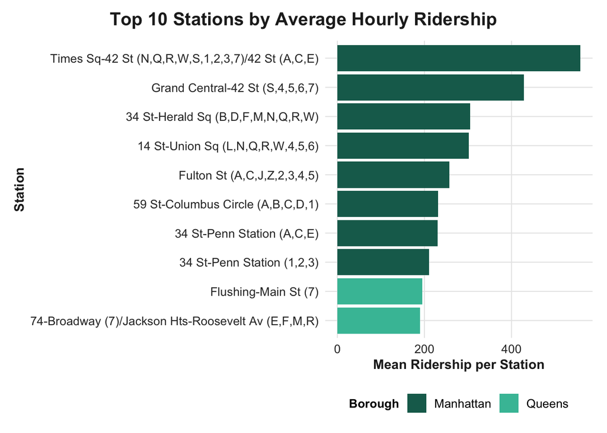

```r
top_stations <- project %>%
  group_by(station_complex, station_complex_id, borough) %>%
  summarize(
    stations_mean_ridership = mean(ridership, na.rm = TRUE),
    .groups = "drop"
  ) %>%
  slice_max(stations_mean_ridership, n = 10, with_ties = FALSE) #So R does not print all 400+ with_ties=False means exactly 10 (even if multiple stations have the same mean ridership)

ggplot(top_stations,
       aes(x = reorder(station_complex, stations_mean_ridership),
           y = stations_mean_ridership, fill = borough)) +
  geom_col() +
  coord_flip() + #Long station names are legible
  scale_fill_manual(
  values = c(
    "Bronx"     = "#D09A3A",
    "Brooklyn"  = "#008C7A",
    "Manhattan" = "#176B5B",
    "Queens"    = "#42BFA5" )
  ) +
  labs(
    title = "Top 10 Stations by Average Hourly Ridership",
    x = "Station",
    y = "Mean Ridership per Station",
    fill = "Borough"
  ) +
  theme_mygraphs()
```

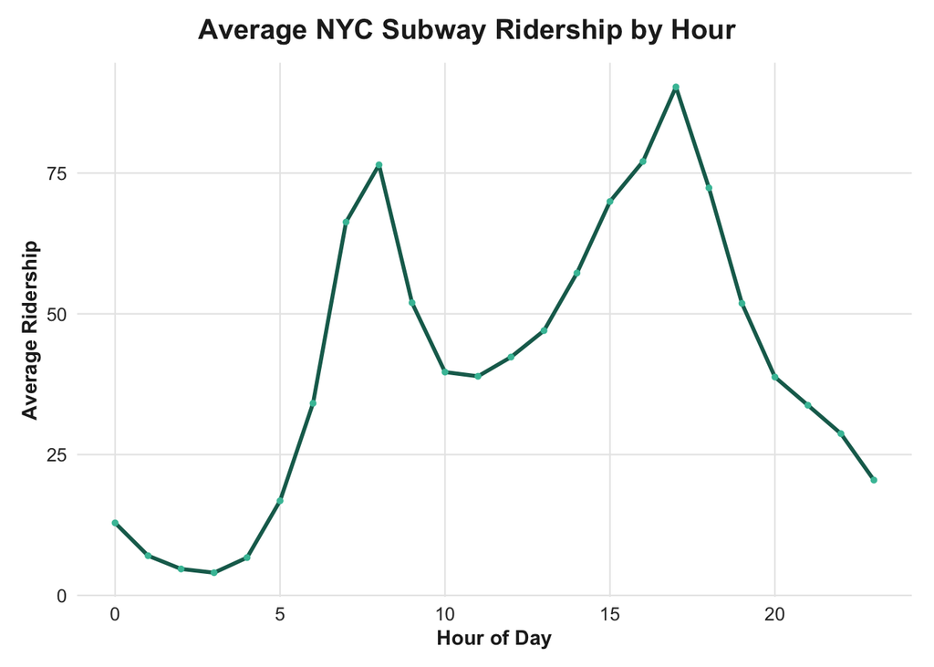

```r
#Using the mean, map over the entire week the average ridership over a 24h period
#Something not quite right here
hourly_mean_ridership <- project %>%
  group_by(transit_timestamp) %>%
  summarize(
    mean_ridership = mean(ridership, na.rm = TRUE),
    .groups = "drop"
  )

average_24hr_ridership <- hourly_mean_ridership %>%
  mutate(
    timestamp = lubridate::mdy_hms(transit_timestamp),
    hour = lubridate::hour(timestamp)
  ) %>%
  group_by(hour) %>%
  summarize(
    mean_ridership = mean(mean_ridership, na.rm = TRUE),
    .groups = "drop"
  ) %>%
  arrange(hour)

day_mean_graph <- ggplot(average_24hr_ridership, aes(x = hour, y = mean_ridership)) +
  geom_line(color = "#176B5B",linewidth = 1) +
  geom_point(color = "#42BFA5",size = 1) +
  labs(
    title = "Average NYC Subway Ridership by Hour",
    x = "Hour of Day",
    y = "Average Ridership"
  ) +
  theme_mygraphs()

day_mean_graph
```

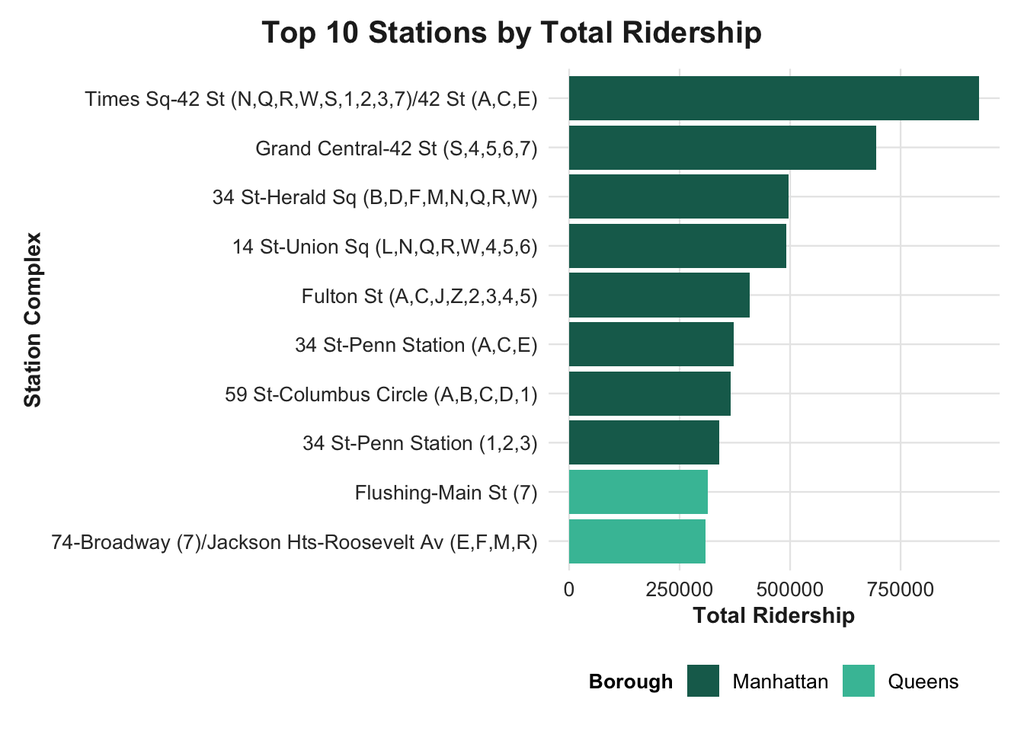

```r
#Total ridership by station
station_total_ridership <- project %>%
  group_by(borough, station_complex) %>%
  summarize(
    total_ridership = sum(ridership, na.rm = TRUE),
    .groups = "drop"
  ) %>%
  arrange(desc(total_ridership))

#
ggplot(
  station_total_ridership %>% slice_max(total_ridership, n = 10),
  aes(
    x = reorder(station_complex, total_ridership),
    y = total_ridership,
    fill = borough
  )
) +
  geom_col() +
  coord_flip() +
    scale_fill_manual(
  values = c(
    "Bronx"     = "#6B8E72",
    "Brooklyn"  = "#008C7A",
    "Manhattan" = "#176B5B",
    "Queens"    = "#42BFA5" )
  ) +
  labs(
    title = "Top 10 Stations by Total Ridership",
    x = "Station Complex",
    y = "Total Ridership",
    fill = "Borough"
  ) +
  theme_mygraphs()
```

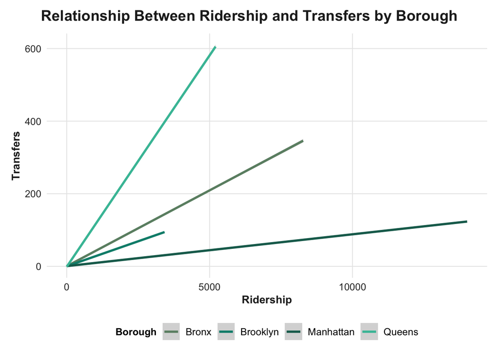

```r
scatter <- project %>%
  ggplot(aes(x=ridership, y=transfers, color=borough)) +
  geom_smooth(method = "lm") +
   scale_color_manual(
  values = c(
    "Bronx"     = "#6B8E72",
    "Brooklyn"  = "#008C7A",
    "Manhattan" = "#176B5B",
    "Queens"    = "#42BFA5" )
  ) +
  labs(
    title = "Relationship Between Ridership and Transfers by Borough",
    x = "Ridership",
    y = "Transfers",
    color = "Borough"
  ) +
  theme_mygraphs()


scatter
```

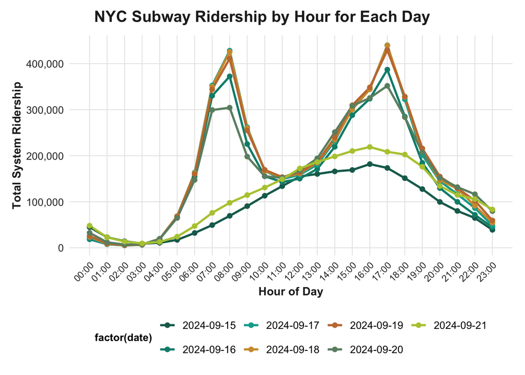

```r
project <- project %>%
  mutate(
    timestamp = mdy_hms(transit_timestamp),
    hour = hour(timestamp)
  )

#Sum of system ridership for each hour of each day
daily_hourly_ridership <- project %>%
  mutate(date = as.Date(timestamp)) %>%
  group_by(date, hour) %>%
  summarize(
    total_ridership = sum(ridership, na.rm = TRUE),
    .groups = "drop"
  )

#Line plot
ggplot(
  daily_hourly_ridership,
  aes(
    x = hour,
    y = total_ridership,
    color = factor(date),
    group = date
  )
) +
  geom_line(linewidth = 1) +
  geom_point(size = 1.8) +
  scale_x_continuous(
    breaks = 0:23, #To have all the hours displayed
    labels = sprintf("%02d:00", 0:23) #24 hour format
  ) +
  scale_y_continuous(labels = scales::comma) + #Adds commas to the numbers on the axis
scale_color_manual(
  values = c(
    "#176B5B",  # Dark teal
    "#008C7A",  # Teal
    "#00A99D",  # Turquoise
    "#D09A3A",  # Muted gold
    "#C47A3C",  # Light brown
    "#6B8E72",  # Sage
    "#B5C83E"   # Yellow green
  )
)+
  labs(
    title = "NYC Subway Ridership by Hour for Each Day",
    x = "Hour of Day",
    y = "Total System Ridership"
  ) +
  theme_mygraphs()+
  theme(
    axis.text.x = element_text(
      angle = 45,
      hjust = 1,
      vjust = 1,
      size = 9
    )
  )
```

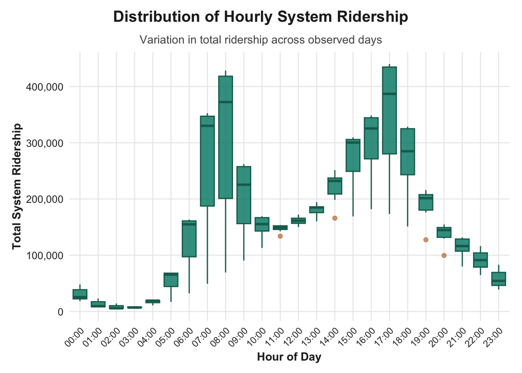

```r
ggplot(
  daily_hourly_ridership,
  aes(x = factor(hour), y = total_ridership)
) +
  geom_boxplot(
    fill = "#008C7A",
    color = "#176B5B",
    alpha = 0.85,
    outlier.color = "#C47A3C",
    outlier.alpha = 0.7
  ) +
  scale_y_continuous(labels = scales::comma) +
  scale_x_discrete(
    labels = sprintf("%02d:00", 0:23)
  ) +
  labs(
    title = "Distribution of Hourly System Ridership",
    subtitle = "Variation in total ridership across observed days",
    x = "Hour of Day",
    y = "Total System Ridership"
  ) +
  theme_mygraphs() +
  theme(
    axis.text.x = element_text(
      angle = 45,
      hjust = 1,
      size = 9
    )
  )
```

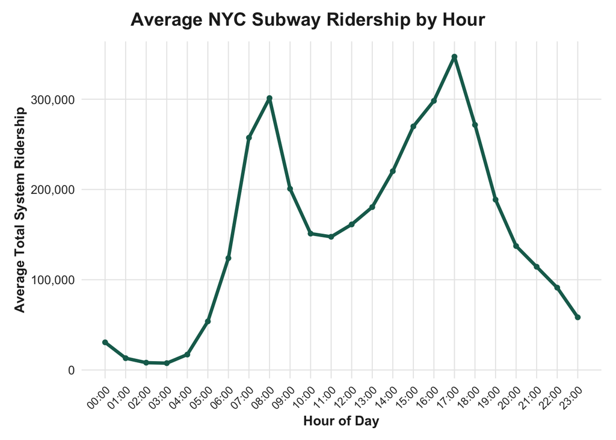

```r
#System ridership for each hour across all days (weekend + weekday)
average_hourly_ridership <- daily_hourly_ridership %>%
  group_by(hour) %>%
  summarize(
    mean_ridership = mean(total_ridership, na.rm = TRUE),
    .groups = "drop"
  )

#Line plot
ggplot(
  average_hourly_ridership,
  aes(x = hour, y = mean_ridership)
) +
  geom_line(color = "#176B5B", linewidth = 1.3) +
  geom_point(color = "#176B5B", size = 1.5) +
  scale_x_continuous(
    breaks = 0:23,
    labels = sprintf("%02d:00", 0:23)
  ) +
  scale_y_continuous(labels = scales::comma) +
  labs(
    title = "Average NYC Subway Ridership by Hour",
    x = "Hour of Day",
    y = "Average Total System Ridership"
  ) +
  theme_mygraphs()+
  theme(
    axis.text.x = element_text(
      angle = 45,
      hjust = 1,
      vjust = 1,
      size = 9
    )
  )
```

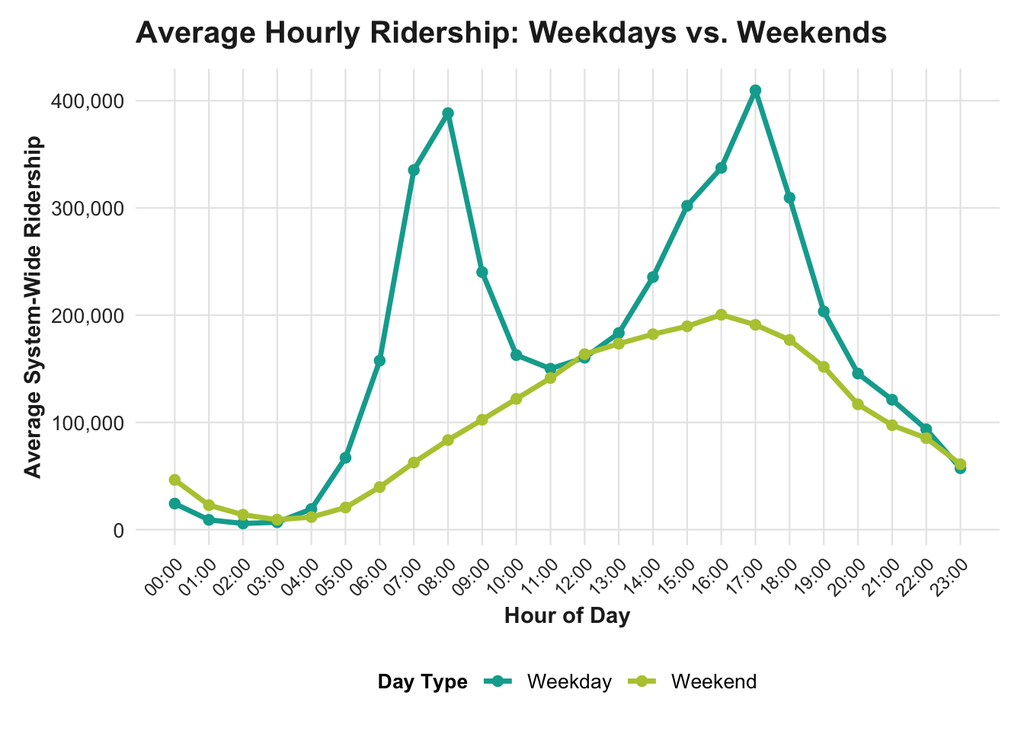

```r
#Sum ridership, then group for type of day, then average of every hour of those groups
average_by_day_type <- project %>%
  mutate(date = as.Date(timestamp)) %>%
  group_by(date, hour, day_type) %>%
  summarize(
    total_ridership = sum(ridership, na.rm = TRUE),
    .groups = "drop"
  ) %>%
  group_by(day_type, hour) %>%
  summarize(
    mean_ridership = mean(total_ridership, na.rm = TRUE),
    .groups = "drop"
  )

#Line graph
ggplot(
  average_by_day_type,
  aes(
    x = hour,
    y = mean_ridership,
    color = day_type,
    group = day_type
  )
) +
  geom_line(linewidth = 1.2) +
  geom_point(size = 2) +
  scale_color_manual(
    values = c(
      "Weekday" = "#00A99D",
      "Weekend" = "#B5C83E"
    )
  ) +
  scale_x_continuous(
    breaks = 0:23,
    labels = sprintf("%02d:00", 0:23)
  ) +
  scale_y_continuous(labels = scales::comma) +
  labs(
    title = "Average Hourly Ridership: Weekdays vs. Weekends",
    x = "Hour of Day",
    y = "Average System-Wide Ridership",
    color = "Day Type"
  ) +
  theme_mygraphs() +
  theme(
    axis.text.x = element_text(
      angle = 45,
      hjust = 1,
      vjust = 1,
      size = 9
    )
  )
```

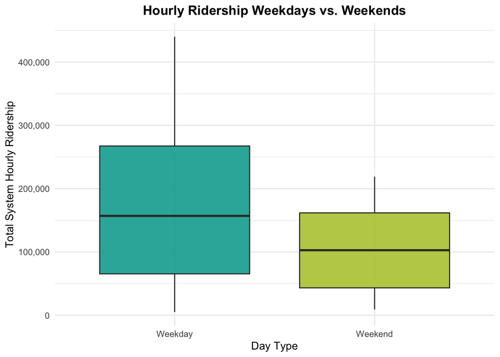

```r
system_hourly_day <- project %>%
  group_by(timestamp, day_type) %>%
  summarize(
    total_ridership = sum(ridership, na.rm = TRUE),
    .groups = "drop"
  )

#Plot
ggplot(system_hourly_day,
       aes(x = day_type, y = total_ridership, fill = day_type)) +
  geom_boxplot(alpha = 0.9) +
  scale_fill_manual(values = c("Weekday" = "#00A99D",
                               "Weekend" = "#B5C83E")) +
  scale_y_continuous(labels = scales::comma) +
  labs(
    title = "Hourly Ridership Weekdays vs. Weekends",
    x = "Day Type",
    y = "Total System Hourly Ridership"
  ) +
  theme_minimal() +
  theme(
    plot.title = element_text(face = "bold", hjust = 0.5),
    legend.position = "none"
  )
```

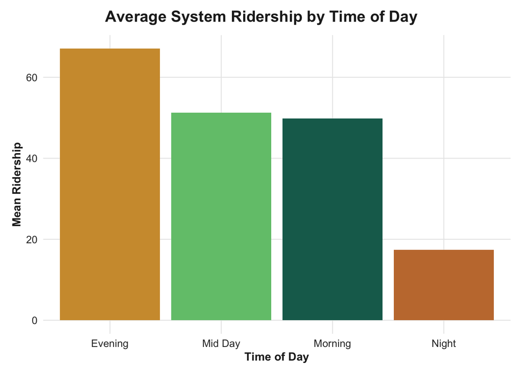

```r
time_of_day_ridership <- project %>%
  group_by(time_of_day) %>%
  summarize(
    mean_ridership = mean(ridership, na.rm = TRUE),
    .groups = "drop"
  )

ggplot(time_of_day_ridership,
       aes(x = time_of_day, y = mean_ridership, fill = time_of_day)) +
  geom_col() +
  scale_fill_manual(values = c(
    "Morning" = "#176B5B",
    "Mid Day" = "#72C47A",
    "Evening" = "#D09A3A",
    "Night" = "#C47A3C"
  )) +
  labs(
    title = "Average System Ridership by Time of Day",
    x = "Time of Day",
    y = "Mean Ridership"
  ) +
  theme_mygraphs() +
    theme(legend.position = "none")
```

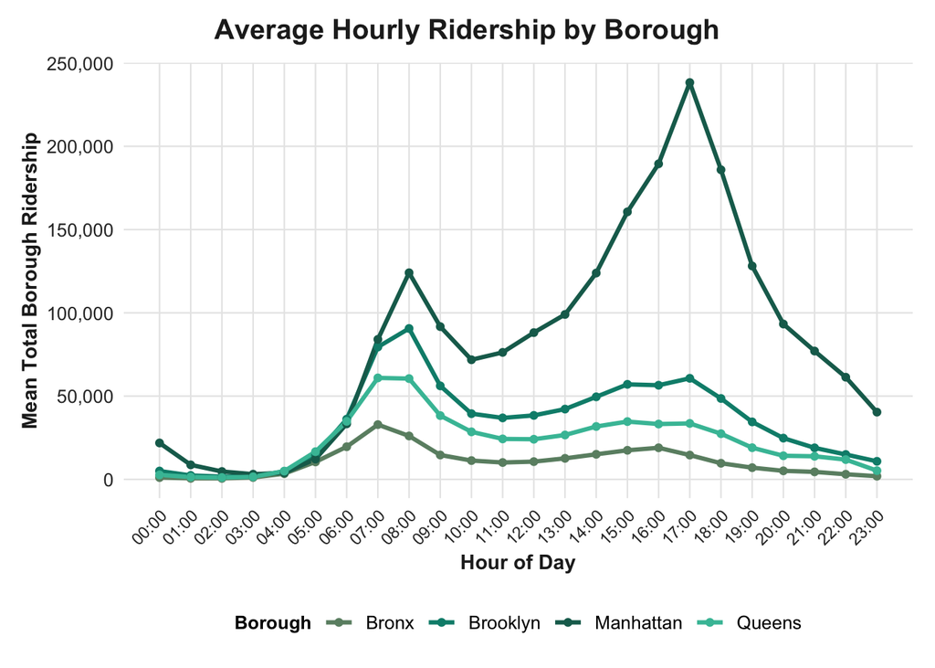

```r
borough_hourly <- project %>%
  group_by(borough, timestamp, hour) %>%
  summarize(
    total_ridership = sum(ridership, na.rm = TRUE),
    .groups = "drop"
  ) %>%
  group_by(borough, hour) %>%
  summarize(
    mean_ridership = mean(total_ridership, na.rm = TRUE),
    .groups = "drop"
  )

#Line graph
ggplot(borough_hourly,
       aes(x = hour, y = mean_ridership, color = borough)) +
  geom_line(linewidth = 1.1) +
  geom_point(size = 1.5) +
   scale_color_manual(
   values = c(
    "Bronx"     = "#6B8E72",
    "Brooklyn"  = "#008C7A",
    "Manhattan" = "#176B5B",
    "Queens"    = "#42BFA5" )
  ) +
  scale_x_continuous(
    breaks = 0:23,
    labels = sprintf("%02d:00", 0:23)
  ) +
  scale_y_continuous(labels = scales::comma) +
  labs(
    title = "Average Hourly Ridership by Borough",
    x = "Hour of Day",
    y = "Mean Total Borough Ridership",
    color = "Borough"
  ) +
  theme_mygraphs() +
  theme(
    axis.text.x = element_text(
      angle = 45,
      hjust = 1,
      vjust = 1,
      size = 9
    )
  )
```

```r
#Station ridership
project %>%
  summarize(
    median = median(ridership, na.rm = TRUE),
    IQR = IQR(ridership, na.rm = TRUE),
    standard_deviation = sd(ridership, na.rm = TRUE),
    minimum = min(ridership, na.rm = TRUE),
    maximum = max(ridership, na.rm = TRUE)
  )
```

```
##   median IQR standard_deviation minimum maximum
## 1     10  27           187.4403       1   14012
```

```r
#Station transfers
project %>%
  summarize(
    median = median(transfers, na.rm = TRUE),
    IQR = IQR(transfers, na.rm = TRUE),
    standard_deviation = sd(transfers, na.rm = TRUE),
    minimum = min(transfers, na.rm = TRUE),
    maximum = max(transfers, na.rm = TRUE)
  )
```

```
##   median IQR standard_deviation minimum maximum
## 1      0   0           11.29689       0    1350
```

## Hypothesis Testing

Questions of interest:

- “How do NYC subway ridership volumes vary throughout the day during the week of September 15-21, 2024?” – Anova and post hoc
- Which hours have the highest ridership average (weekdays vs. weekends)?
- Do these hours correspond to commuting periods?

**T-Tests: Commute vs. Non-commute; Weekday vs. Weekend**

```r
hourly_ridership <- project %>%
  mutate(commute_period = if_else(commute_type %in% c("Morning Commute", "Evening Commute"), "Commute","Non-Commute")) %>%
  group_by(timestamp, day_type, time_of_day, commute_period) %>%
  summarize(total_ridership = sum(ridership, na.rm = TRUE), .groups = "drop")

hourly_ridership
```

```
## # A tibble: 168 × 5
##    timestamp           day_type time_of_day commute_period total_ridership
##    <dttm>              <fct>    <fct>       <chr>                    <dbl>
##  1 2024-09-15 00:00:00 Weekend  Night       Non-Commute              44758
##  2 2024-09-15 01:00:00 Weekend  Night       Non-Commute              23003
##  3 2024-09-15 02:00:00 Weekend  Night       Non-Commute              14301
##  4 2024-09-15 03:00:00 Weekend  Night       Non-Commute               9080
##  5 2024-09-15 04:00:00 Weekend  Night       Non-Commute              10771
##  6 2024-09-15 05:00:00 Weekend  Morning     Non-Commute              17150
##  7 2024-09-15 06:00:00 Weekend  Morning     Non-Commute              32162
##  8 2024-09-15 07:00:00 Weekend  Morning     Non-Commute              49306
##  9 2024-09-15 08:00:00 Weekend  Morning     Non-Commute              69387
## 10 2024-09-15 09:00:00 Weekend  Morning     Non-Commute              90511
## # ℹ 158 more rows
```

Commute vs. Non-commute time periods:

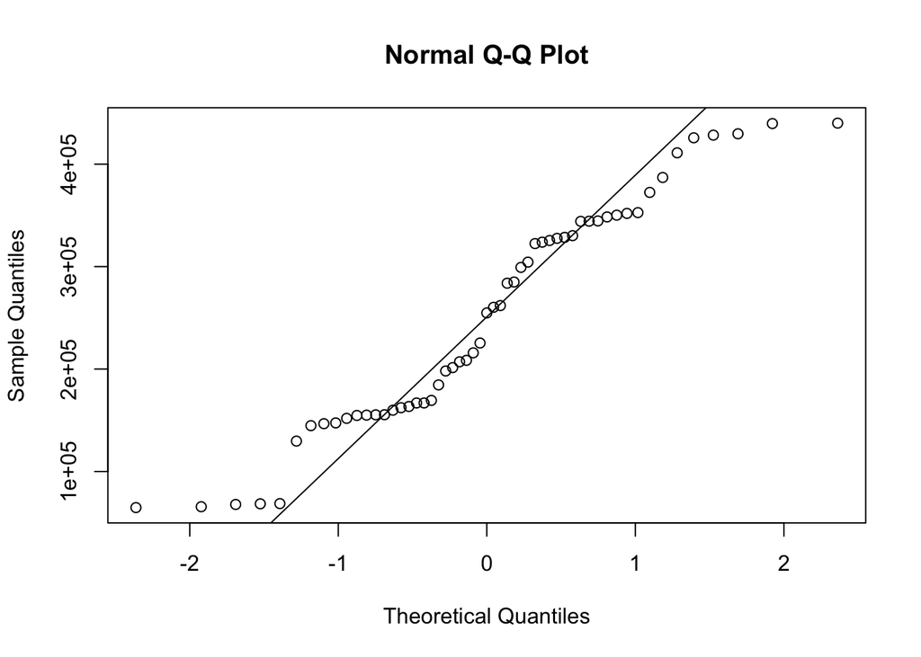

```r
qqnorm(hourly_ridership$total_ridership[hourly_ridership$commute_period == "Commute"])
qqline(hourly_ridership$total_ridership[hourly_ridership$commute_period == "Commute"])
```

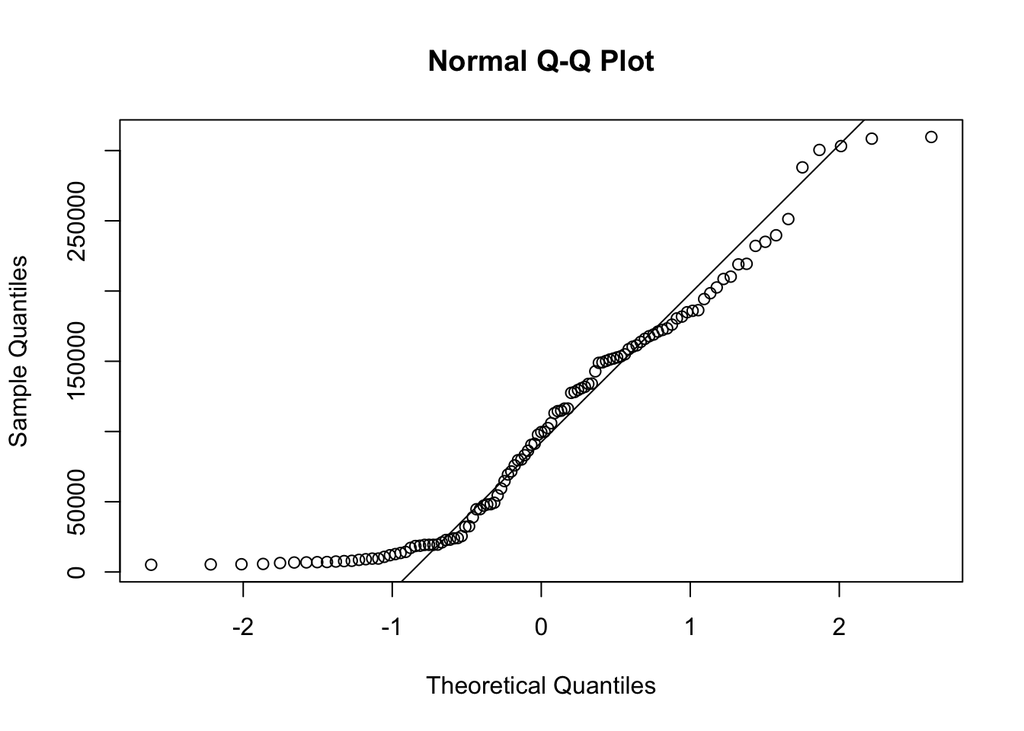

```r
qqnorm(hourly_ridership$total_ridership[hourly_ridership$commute_period == "Non-Commute"])
qqline(hourly_ridership$total_ridership[hourly_ridership$commute_period == "Non-Commute"])
```

Weekday vs. Weekend periods:

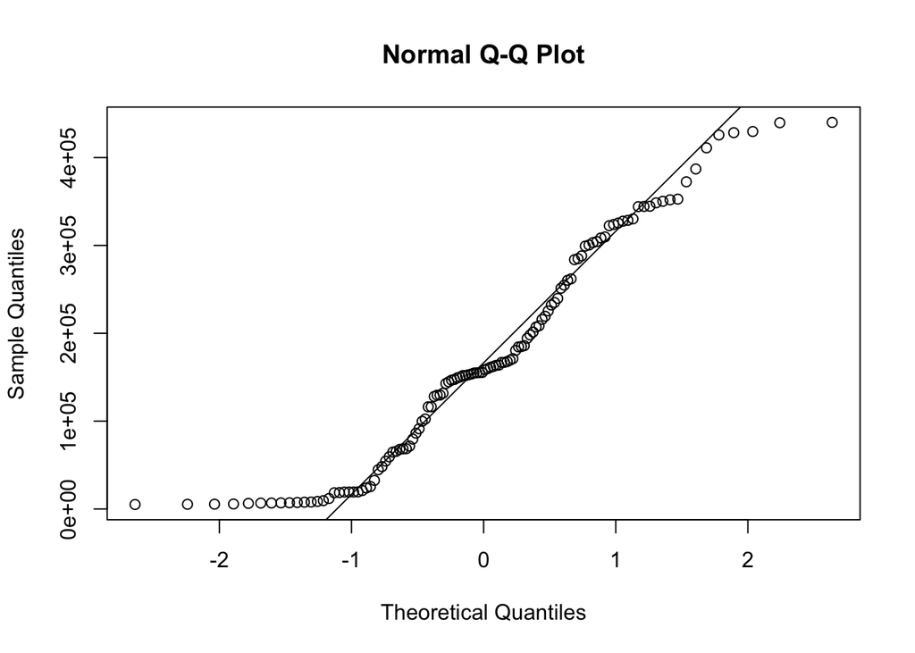

```r
qqnorm(hourly_ridership$total_ridership[hourly_ridership$day_type == "Weekday"])
qqline(hourly_ridership$total_ridership[hourly_ridership$day_type == "Weekday"])
```

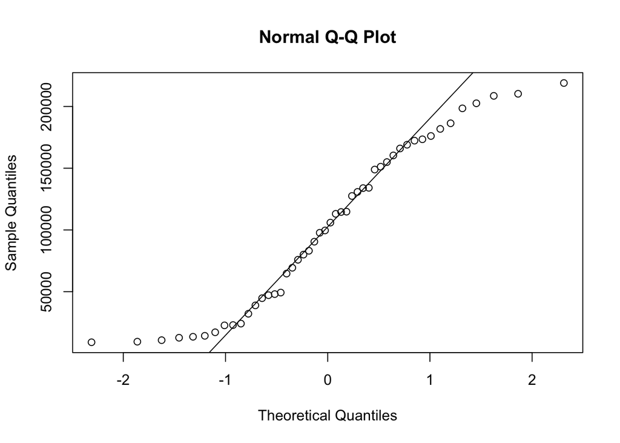

```r
qqnorm(hourly_ridership$total_ridership[hourly_ridership$day_type == "Weekend"])
qqline(hourly_ridership$total_ridership[hourly_ridership$day_type == "Weekend"])
```

Assumptions check for t-tests:

- Commute vs. Non-commute time
  - We do not know the population SD (we took a sample of a typical week with no holidays or off season periods)
  - Sample size is large enough (per the CLT) for the test to be robust against normality violations
  - Independent observation assumption may be violated due to time data, but continue with t-test for this class
- Weekday vs. Weekend
  - We do not know the population SD (we took a sample of a typical week with no holidays or off season periods)
  - Sample size is large enough (per the CLT) for the test to be robust against normality violations
  - Independent observation assumption may be violated due to time data, but continue with t-test for this class

```r
# t-test for commute time vs. non-commute time means
commute_period_test <- t.test(total_ridership ~ commute_period, data = hourly_ridership)
commute_period_test
```

```
##
##  Welch Two Sample t-test
##
## data:  total_ridership by commute_period
## t = 8.7228, df = 84.945, p-value = 1.975e-13
## alternative hypothesis: true difference in means between group Commute and group Non-Commute is not equal to 0
## 95 percent confidence interval:
##  113029.8 179771.2
## sample estimates:
##     mean in group Commute mean in group Non-Commute
##                  250605.0                  104204.5
```

Null hypothesis: Mean hourly ridership of commute periods = Mean hourly ridership of non-commute periods

Alternative hypothesis: Mean hourly ridership of commute periods ≠ Mean hourly ridership of non-commute periods

```r
# t-test for weekday vs. weekend means
weekday_weekend_test <- t.test(total_ridership ~ day_type, data = hourly_ridership)
weekday_weekend_test
```

```
##
##  Welch Two Sample t-test
##
## data:  total_ridership by day_type
## t = 4.641, df = 152.69, p-value = 7.411e-06
## alternative hypothesis: true difference in means between group Weekday and group Weekend is not equal to 0
## 95 percent confidence interval:
##  39700.86 98553.65
## sample estimates:
## mean in group Weekday mean in group Weekend
##              171883.8              102756.6
```

Null hypothesis: Mean hourly ridership of Weekdays = Mean hourly ridership of weekends

Alternative hypothesis: Mean hourly ridership of Weekdays ≠ Mean hourly ridership of weekends

Alpha = 0.05 > P-value = 7.411e-06 –> Reject the null hypothesis. There is sufficient evidence to conclude that the mean hourly ridership on weekdays is different that the mean hourly ridership of weekends

**ANOVA: Differences in mean hourly ridership between time-of-day categories**

ANOVA Assumptions Check:

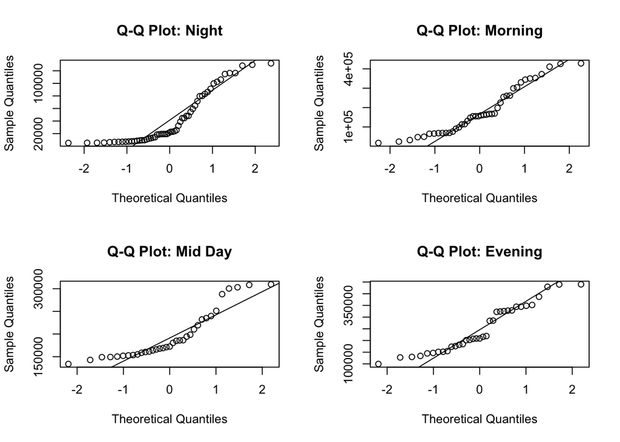

```r
par(mfrow = c(2, 2))

for (time_category in unique(hourly_ridership$time_of_day)) {
  x <- hourly_ridership$total_ridership[hourly_ridership$time_of_day == time_category]
  qqnorm(x, main = paste("Q-Q Plot:", time_category))
  qqline(x)
}
```

```r
leveneTest(total_ridership ~ time_of_day, data = hourly_ridership)
```

```
## Levene's Test for Homogeneity of Variance (center = median)
##        Df F value    Pr(>F)
## group   3   14.37 2.338e-08 ***
##       164
## ---
## Signif. codes:  0 '***' 0.001 '**' 0.01 '*' 0.05 '.' 0.1 ' ' 1
```

- Normality, homogeneity of variances, independence of errors
  - All three assumptions may be violated based on the checks conducted.
    - QQ plots show deviation from normality, but sample sizes are large enough for test to be robust
    - Levene’s test shows heteroscedasticity
    - Our sample was specifically selected not at random
  - This may be a limitation of this ANOVA analysis

```r
time_anova <- aov(total_ridership ~ time_of_day, data = hourly_ridership)
summary(time_anova)
```

```
##              Df    Sum Sq   Mean Sq F value Pr(>F)
## time_of_day   3 1.101e+12 3.671e+11   53.72 <2e-16 ***
## Residuals   164 1.121e+12 6.833e+09
## ---
## Signif. codes:  0 '***' 0.001 '**' 0.01 '*' 0.05 '.' 0.1 ' ' 1
```

Null hypothesis: Mean hourly ridership during morning = Mean hourly ridership during midday = Mean hourly ridership during evening = Mean hourly ridership during night

Alternative hypothesis: The mean hourly ridership of at least one time of day category is different than the others.

Alpha = 0.05 > P-value = <2e-16 –> Reject the null hypothesis. There is sufficient evidence to conclude that at least one time category group has a different mean hourly ridership than the others.

```r
time_post_hoc <- TukeyHSD(time_anova)
time_post_hoc
```

```
##   Tukey multiple comparisons of means
##     95% family-wise confidence level
##
## Fit: aov(formula = total_ridership ~ time_of_day, data = hourly_ridership)
##
## $time_of_day
##                       diff        lwr         upr     p adj
## Mid Day-Evening  -52696.43 -103984.46   -1408.397 0.0415268
## Morning-Evening  -67218.61 -116323.16  -18114.058 0.0027759
## Night-Evening   -206050.59 -252280.99 -159820.179 0.0000000
## Morning-Mid Day  -14522.18  -63626.73   34582.371 0.8689305
## Night-Mid Day   -153354.16 -199584.56 -107123.750 0.0000000
## Night-Morning   -138831.98 -182627.47  -95036.482 0.0000000
```

Post hoc conclusions: - At the alpha = 0.05 level, the time periods pairings that have a significant difference are: - Midday and Evening - Morning and Evening - Night and evening - Night and midday - Night and morning - Out of these, I think the notable differences in pairs are midday and evening and morning and evening (it makes sense that night is significantly lower than the others).

**ANOVA: Differences in daily ridership between boroughs**

```r
# Daily ridership total for each borough
borough_daily <- project %>%
  mutate(date = as.Date(timestamp)) %>%
  group_by(date, borough) %>%
  summarize(total_ridership = sum(ridership, na.rm = TRUE), .groups = "drop")
```

ANOVA Assumptions Check:

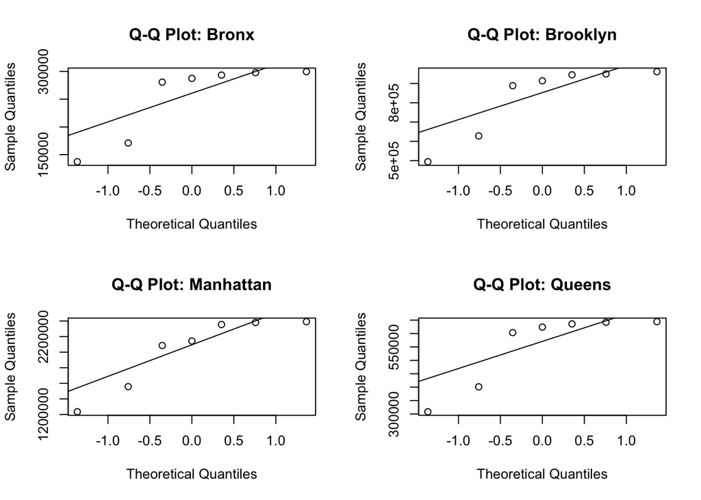

```r
par(mfrow = c(2, 2))

for (b in unique(borough_daily$borough)) {
  x <- borough_daily$total_ridership[borough_daily$borough == b]
  qqnorm(x, main = paste("Q-Q Plot:", b))
  qqline(x)
}
```

```r
leveneTest(total_ridership ~ borough, data = borough_daily)
```

```
## Levene's Test for Homogeneity of Variance (center = median)
##       Df F value  Pr(>F)
## group  3  2.8461 0.05885 .
##       24
## ---
## Signif. codes:  0 '***' 0.001 '**' 0.01 '*' 0.05 '.' 0.1 ' ' 1
```

```r
# Daily ridership total for each borough
borough_daily <- project %>%
  mutate(date = as.Date(timestamp)) %>%
  group_by(date, borough) %>%
  summarize(total_ridership = sum(ridership, na.rm = TRUE), .groups = "drop")
```

```r
# ANOVA test: Do daily averages in each borough differ?
borough_anova <- aov(total_ridership ~ borough, data = borough_daily)
summary(borough_anova)
```

```
##             Df    Sum Sq   Mean Sq F value   Pr(>F)
## borough      3 1.262e+13 4.208e+12   63.86 1.38e-11 ***
## Residuals   24 1.581e+12 6.589e+10
## ---
## Signif. codes:  0 '***' 0.001 '**' 0.01 '*' 0.05 '.' 0.1 ' ' 1
```

Null hypothesis: Mean daily ridership in Manhattan = Mean daily ridership in Brooklyn = Mean daily ridership in Queens = Mean daily ridership in the Bronx

Alternative hypothesis: The mean daily ridership of at least one borough is different than the others.

Alpha = 0.05 > P-value = 1.38e-11 –> Reject the null hypothesis. There is sufficient evidence to conclude that at least one borough has a different mean daily ridership than the other boroughs.

```r
borough_post_hoc <- TukeyHSD(borough_anova)
borough_post_hoc
```

```
##   Tukey multiple comparisons of means
##     95% family-wise confidence level
##
## Fit: aov(formula = total_ridership ~ borough, data = borough_daily)
##
## $borough
##                          diff         lwr        upr     p adj
## Brooklyn-Bronx       573430.0   194933.82   951926.2 0.0017792
## Manhattan-Bronx     1768942.0  1390445.82  2147438.2 0.0000000
## Queens-Bronx         298801.9   -79694.32   677298.0 0.1581908
## Manhattan-Brooklyn  1195512.0   817015.82  1574008.2 0.0000000
## Queens-Brooklyn     -274628.1  -653124.32   103868.0 0.2153342
## Queens-Manhattan   -1470140.1 -1848636.32 -1091644.0 0.0000000
```

Post hoc conclusions: - At the alpha = 0.05 level, the borough pairings that have a significant difference are: - Brooklyn and the Bronx - Manhattan and the Bronx - Manhattan and Brooklyn - Queens and Manhattan - Manhattan’s mean daily ridership differs significantly from the mean daily ridership in all other boroughs

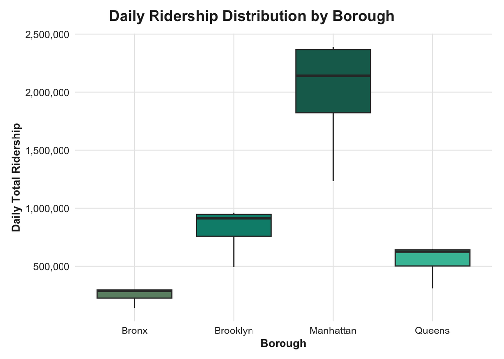

```r
ggplot(borough_daily,
       aes(x = borough, y = total_ridership, fill = borough)) +
  geom_boxplot() +
  scale_fill_manual(values = c(
    "Bronx" = "#6B8E72",
    "Brooklyn" = "#008C7A",
    "Manhattan" = "#176B5B",
    "Queens" = "#42BFA5"
  )) +
  scale_y_continuous(labels = scales::comma) +
  labs(
    title = "Daily Ridership Distribution by Borough",
    x = "Borough",
    y = "Daily Total Ridership"
  ) +
  theme_mygraphs() +
  theme(legend.position = "none")
```

# Transfers EDA, total and average bus to station transfers

```r
project %>%
  group_by(station_complex, station_complex_id) %>%
  summarize(
    total_transfers = sum(transfers, na.rm = TRUE),
    average_transfers = mean(transfers, na.rm = TRUE),
    observations = n()
  ) %>%
  arrange(desc(total_transfers))
```

```
## # A tibble: 424 × 5
## # Groups:   station_complex [424]
##    station_complex          station_complex_id total_transfers average_transfers
##    <chr>                                 <int>           <dbl>             <dbl>
##  1 Flushing-Main St (7)                    447           72276             44.9
##  2 Jamaica Center-Parsons/…                278           39801             26.1
##  3 Kew Gardens-Union Tpke …                259           28726             18.6
##  4 74-Broadway (7)/Jackson…                616           27347             16.8
##  5 Jamaica-179 St (F)                      254           25531             17.2
##  6 Lexington Av (N,R,W)/59…                613           17435             11.3
##  7 South Ferry (1)/Whiteha…                635           16319             10.6
##  8 Forest Hills-71 Av (E,F…                261           15453              9.90
##  9 161 St-Yankee Stadium (…                604           15017              9.60
## 10 Flatbush Av-Brooklyn Co…                359           14005              9.42
## # ℹ 414 more rows
## # ℹ 1 more variable: observations <int>
```

#Hourly total transfers by borough in one graph

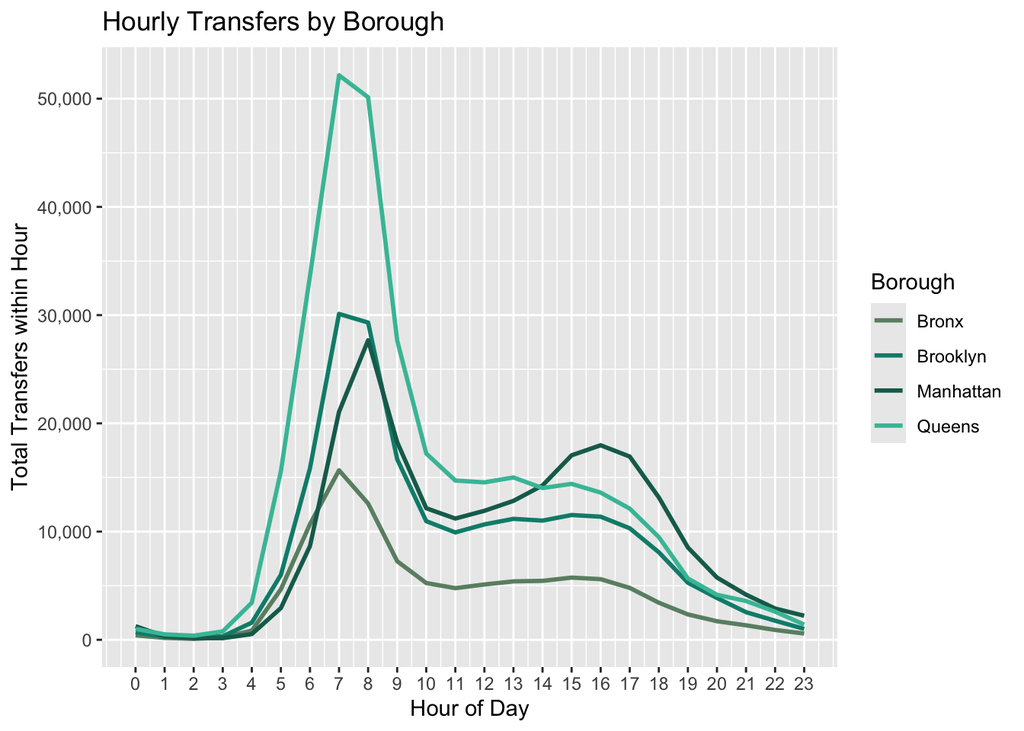

```r
hourly_transfers_total <- project %>%
  group_by(hour, borough) %>%
  summarize(total_hourly_transfers = sum(transfers, na.rm = TRUE),
  .groups = "drop"
)

ggplot(hourly_transfers_total, aes(x = hour, y = total_hourly_transfers, color = borough)) + geom_line(lwd = 1) +
  scale_x_continuous(
    breaks = 0:23, #To have all the hours displayed
  ) +
  scale_y_continuous(labels = scales::comma)+
  scale_color_manual(values = c(
    "Bronx" = "#6B8E72",
    "Brooklyn" = "#008C7A",
    "Manhattan" = "#176B5B",
    "Queens" = "#42BFA5"
  )) +
  labs(
  title = "Hourly Transfers by Borough",
  x = "Hour of Day",
  y = "Total Transfers within Hour",
  color = "Borough"
)
```

All boroughs demonstrate a higher amount of total bus-to-subway transfers during the morning hours. Queens clearly shows the highest number of total transfers, while Manhattan has a noticable bimodal distribution, indicating people take the bus to the subway during the morning and evening timeperiods. #Where are the top 10 Transfer Stations

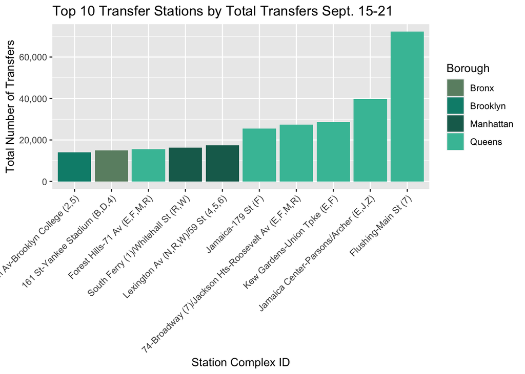

```r
top_transfer_stations <- project %>%
  group_by(station_complex, borough) %>%
  summarize(
    total_transfers = sum(transfers, na.rm = TRUE),
    .groups = "drop"
  ) %>%
  arrange(desc(total_transfers)) %>%
  slice_head(n = 10)

ggplot(top_transfer_stations, aes(x = reorder(station_complex, total_transfers), y = total_transfers, fill = borough)) + geom_col() + scale_fill_manual(values = c(
  "Bronx" = "#6B8E72",
  "Brooklyn" = "#008C7A",
  "Manhattan" = "#176B5B",
  "Queens" = "#42BFA5"
)) +
  scale_y_continuous(labels = scales::comma) +
  labs(
  title = "Top 10 Transfer Stations by Total Transfers Sept. 15-21",
  x = "Station Complex ID",
  y = "Total Number of Transfers",
  fill = "Borough"
) +
  theme(
  axis.text.x = element_text(
    angle = 45,
    hjust = 1,
    vjust = 1
  )
)
```

The top five transfer stations for total number of bus-to-subway transfers are Flushing-Main St (7), Jamaica Center-Parsons/Archer (E,J,Z), Kew Gardens-Union Tpke (E,F), 74-Broadway (7)/Jackson Hts-Roosevelt Av (E,F,M,R), Jamaica-179 St (F), which are all in Queens. Additionally, Flushing-Main St, Jamaica Center-Parsons/Archer, Jamaica-179 St, South Ferry/Whitehall St in Manhattan, and Flatbush Av-Brooklyn College in Brooklyn are the last subway stations on their respective lines, indicating people may take the bus from areas outside of subway map coverage.

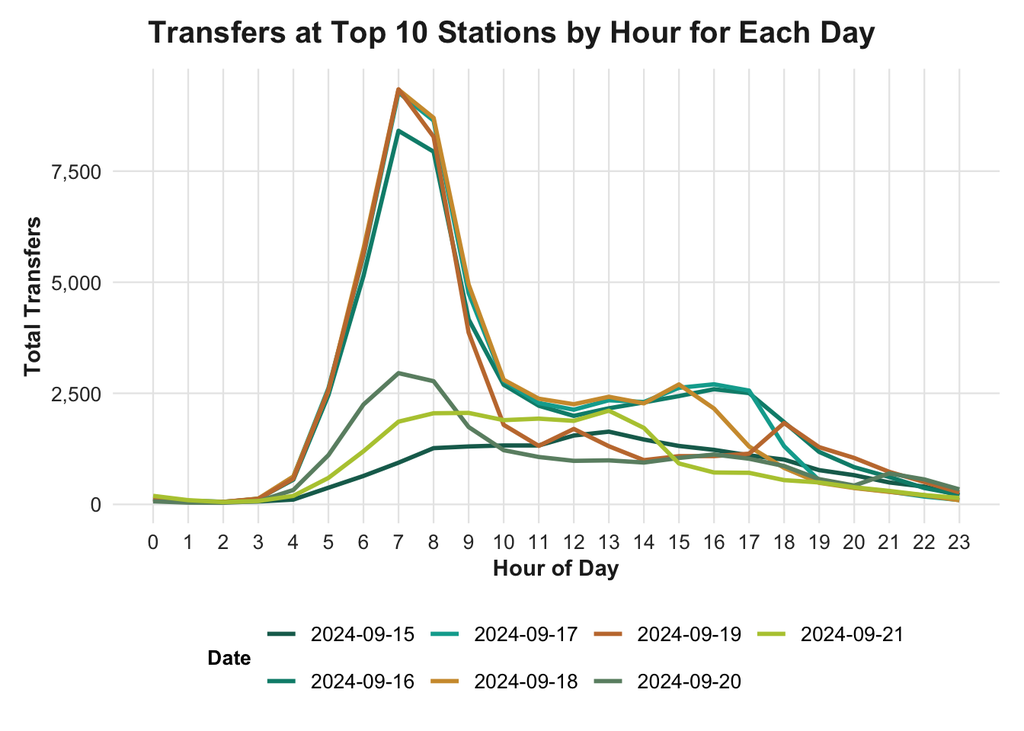

```r
#Sum total transfers at top 10 stations for each hour of each day
daily_hourly_top_transfers <- project %>%
  filter(station_complex %in% top_transfer_stations$station_complex) %>%
  mutate(date = as.Date(timestamp)) %>%
  group_by(date, hour) %>%
  summarize(
    total_transfers = sum(transfers, na.rm = TRUE),
    .groups = "drop"
  )
#Line Graph of daily total transfers by hour at top 10 systems
ggplot(
  daily_hourly_top_transfers,
  aes(
    x = hour,
    y = total_transfers,
    color = factor(date),
    group = date
  )
) +
  geom_line(linewidth = 1) +
  scale_x_continuous(
    breaks = 0:23
  ) +
  scale_y_continuous(labels = scales::comma) + #Adds commas to the numbers on the axis
scale_color_manual(
  values = c(
    "#176B5B",  # Dark teal
    "#008C7A",  # Teal
    "#00A99D",  # Turquoise
    "#D09A3A",  # Muted gold
    "#C47A3C",  # Light brown
    "#6B8E72",  # Sage
    "#B5C83E"   # Yellow green
  )
)+
  labs(
    title = "Transfers at Top 10 Stations by Hour for Each Day",
    x = "Hour of Day",
    y = "Total Transfers",
    color = "Date"
  ) +
  theme_mygraphs()
```

Of the top 10 stations, bus-to-subway transfers during the morning commute are clear on Monday (Sept. 16) to Thursday (Sept. 19).There is a slight curve on Friday (Sept. 20), however, this line is more similar to the Saturday and Sunday lines (Sept. 21 and 15, respectively). This supports that there are difference in morning commuting hours compared to the same time period during the weekend. Additionally, hybrid jobs may allow employees to work remotely on Fridays more often than Monday through Thursday. #Distribution of transfers at top 10 stations by hour

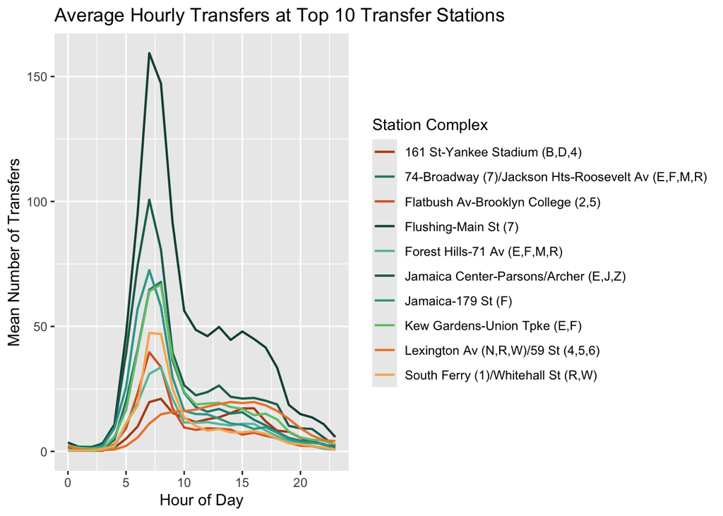

```r
hourly_transfers <- project %>%
  semi_join(
    top_transfer_stations,
    by = c("station_complex")
  ) %>%
  group_by(station_complex, hour) %>%
  summarize(
    mean_transfers = mean(transfers, na.rm = TRUE),
    .groups = "drop"
  )
ggplot(hourly_transfers, aes(x = hour, y = mean_transfers, color = factor(station_complex), group = station_complex)) + geom_line(linewidth = .75) +
  scale_color_manual(
  values = c(
    "#B84A12",  # Yankee
    "#288577",  # 74 Broadway
    "#D96524",  # Flatbush
    "#164E45",  # Flushing
    "#65BFA8",  # Forest Hills-71 Ave
    "#1F6B5B",  # Jamaica Center
    "#36A397",  # Jamaica - 179 St
    "#72C47A",  # Kew Gardens
    "#ED8538",  # Lexington Ave
    "#F5B461"   # South Ferry
  )) +
  labs(
    title = "Average Hourly Transfers at Top 10 Transfer Stations",
    x = "Hour of Day",
    y = "Mean Number of Transfers",
    color = "Station Complex"
  )
```

Flushing-Main St. Station shows an elevated transfer rate through the day and evening. #Weekend vs Weekday Hourly Transfers at All Stations

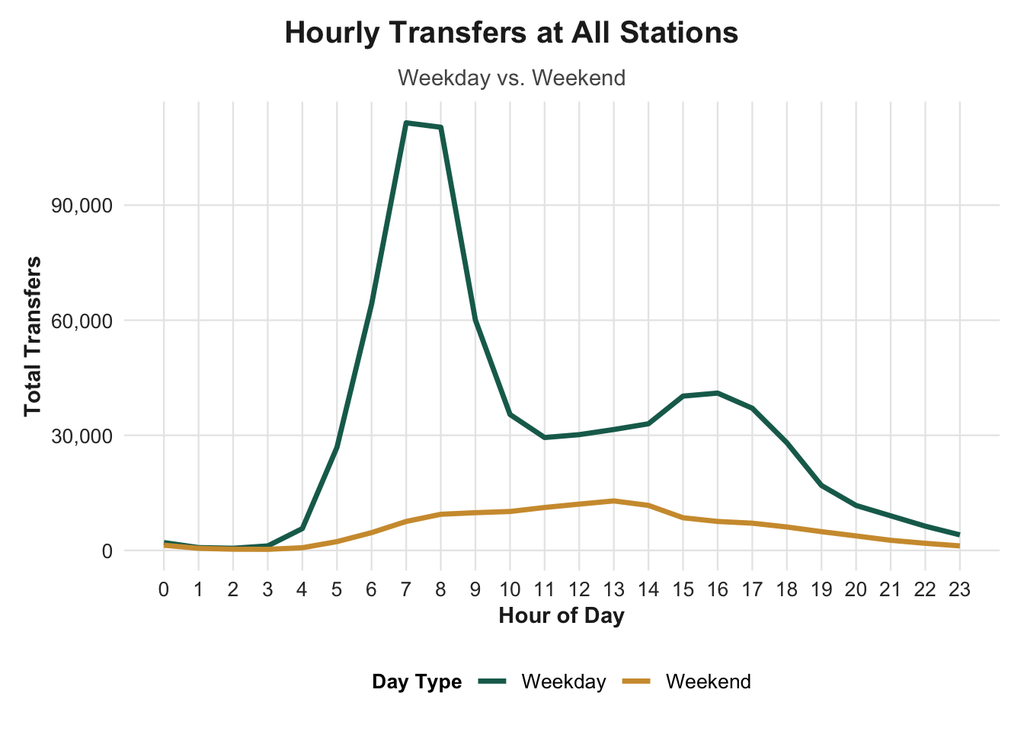

```r
hourly_transfers <- project %>%
  mutate(
    hour = hour(timestamp),
    day_type = if_else(
      wday(timestamp) %in% c(1, 7),
      "Weekend",
      "Weekday"
    )
  ) %>%
  group_by(day_type, hour) %>%
  summarize(
    total_transfers = sum(transfers, na.rm = TRUE),
    .groups = "drop"
  )
ggplot(
  hourly_transfers,
  aes(
    x = hour,
    y = total_transfers,
    color = day_type,
    group = day_type
  )
) +
  geom_line(linewidth = 1.2) +
  scale_color_manual(
    values = c(
      "Weekday" = "#176B5B",
      "Weekend" = "#D09A3A"
    )
  ) +
  scale_x_continuous(
    breaks = 0:23,
  ) +
  scale_y_continuous(
    labels = scales::comma
  ) +
  labs(
    title = "Hourly Transfers at All Stations",
    subtitle = "Weekday vs. Weekend",
    x = "Hour of Day",
    y = "Total Transfers",
    color = "Day Type"
  ) +
  theme_mygraphs()
```

Similar to the Top 10 Subway Stations comparison, there’s a clear difference between weekend and weekday bus-to-subway transfers. Additionally, there is once again a clear increase in the number of people using buses to transfer at subway stations during the morning weekday commute times in comparison to the evening commute times. #QQ Plots for Ridership by Borough

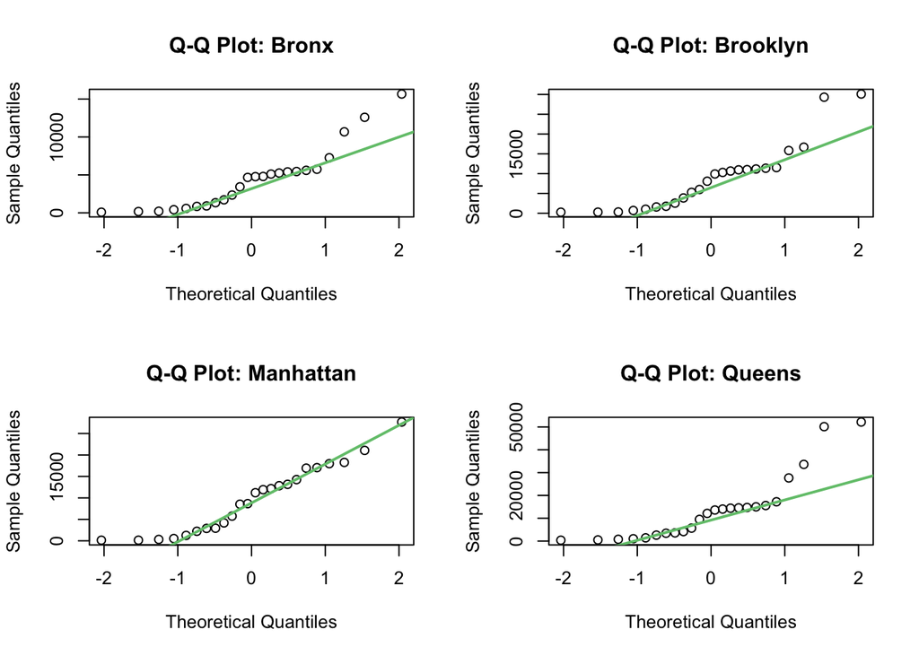

```r
hourly_transfers_total <- project %>%
  group_by(hour, borough) %>%
  summarize(total_hourly_transfers = sum(transfers, na.rm = TRUE),
  .groups = "drop"
)
boroughs <- unique(hourly_transfers_total$borough)
par(mfrow = c(2,2))

for (b in boroughs) {
  borough_data <- hourly_transfers_total$total_hourly_transfers[
    hourly_transfers_total$borough == b
  ]

  qqnorm(borough_data,
         main = paste("Q-Q Plot:", b),
         xlab = "Theoretical Quantiles",
         ylab = "Sample Quantiles")

  qqline(borough_data, col = "#72C47A", lwd = 2)
}
```

```r
par(mfrow = c(1, 1))
```

- Which hours have the highest transfers average (weekdays vs. weekends)?
- Do these hours correspond to commuting periods?

**T-Tests: Commute vs. Non-commute; Weekday vs. Weekend**

```r
hourly_transfers <- project %>%
  mutate(commute_period = if_else(commute_type %in% c("Morning Commute", "Evening Commute"), "Commute","Non-Commute")) %>%
  group_by(timestamp, day_type, time_of_day, commute_period) %>%
  summarize(total_transfers = sum(transfers, na.rm = TRUE), .groups = "drop")

hourly_transfers
```

```
## # A tibble: 168 × 5
##    timestamp           day_type time_of_day commute_period total_transfers
##    <dttm>              <fct>    <fct>       <chr>                    <dbl>
##  1 2024-09-15 00:00:00 Weekend  Night       Non-Commute                594
##  2 2024-09-15 01:00:00 Weekend  Night       Non-Commute                279
##  3 2024-09-15 02:00:00 Weekend  Night       Non-Commute                170
##  4 2024-09-15 03:00:00 Weekend  Night       Non-Commute                143
##  5 2024-09-15 04:00:00 Weekend  Night       Non-Commute                283
##  6 2024-09-15 05:00:00 Weekend  Morning     Non-Commute                856
##  7 2024-09-15 06:00:00 Weekend  Morning     Non-Commute               1693
##  8 2024-09-15 07:00:00 Weekend  Morning     Non-Commute               2723
##  9 2024-09-15 08:00:00 Weekend  Morning     Non-Commute               3622
## 10 2024-09-15 09:00:00 Weekend  Morning     Non-Commute               4005
## # ℹ 158 more rows
```

Commute vs. Non-commute time periods:

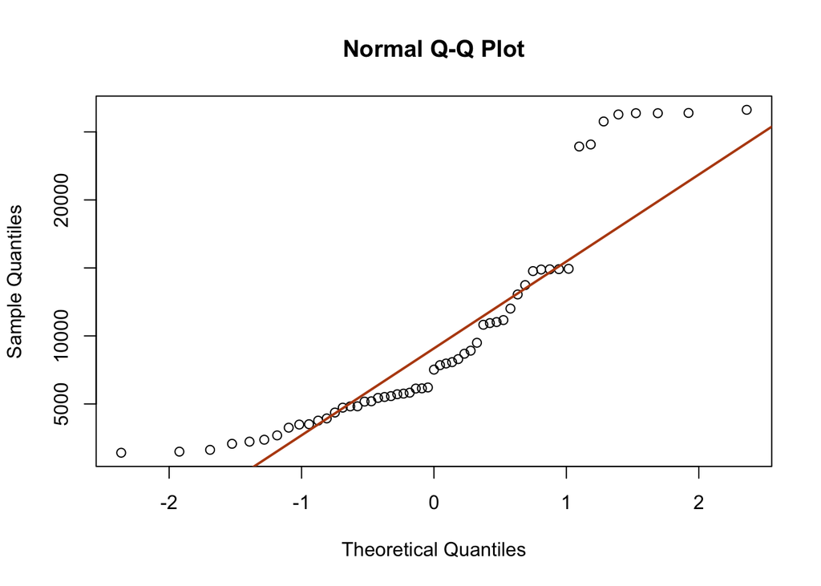

```r
qqnorm(hourly_transfers$total_transfers[hourly_transfers$commute_period == "Commute"])
qqline(hourly_transfers$total_transfers[hourly_transfers$commute_period == "Commute"], col = "#B84A12", lwd = 2)
```

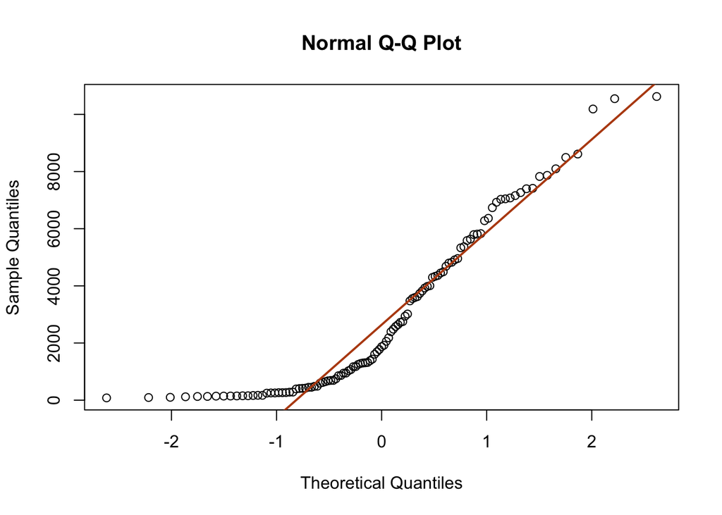

```r
qqnorm(hourly_transfers$total_transfers[hourly_transfers$commute_period == "Non-Commute"])
qqline(hourly_transfers$total_transfers[hourly_transfers$commute_period == "Non-Commute"], col = "#B84A12", lwd = 2)
```

Weekday vs. Weekend periods:

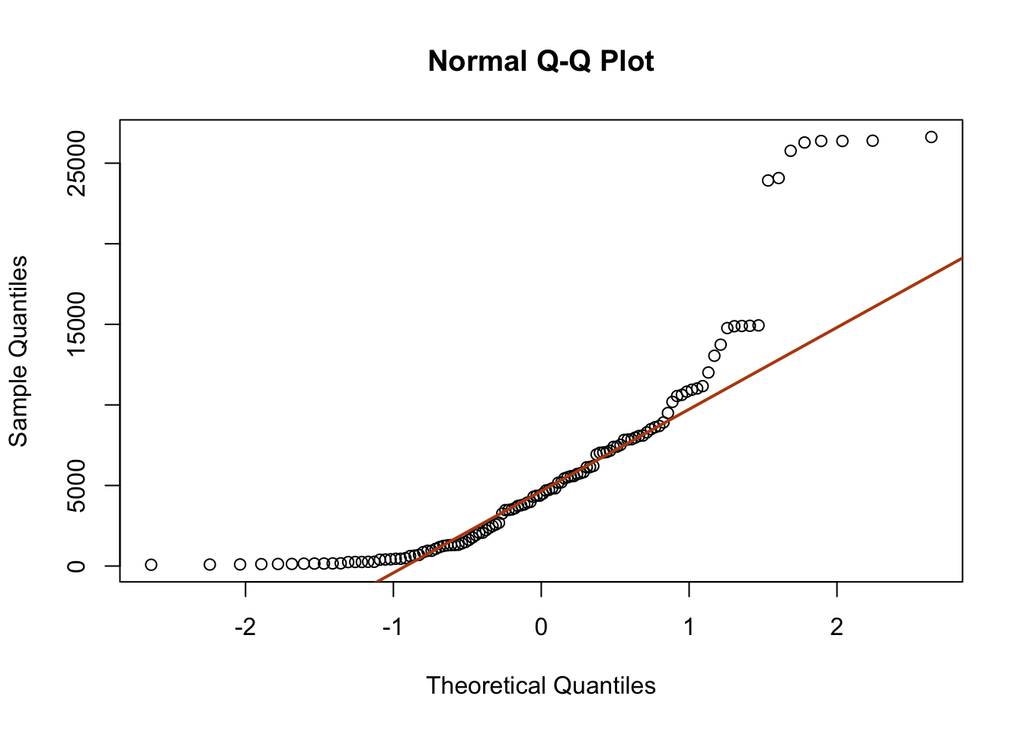

```r
qqnorm(hourly_transfers$total_transfers[hourly_transfers$day_type == "Weekday"])
qqline(hourly_transfers$total_transfers[hourly_transfers$day_type == "Weekday"], col = "#B84A12", lwd = 2)
```

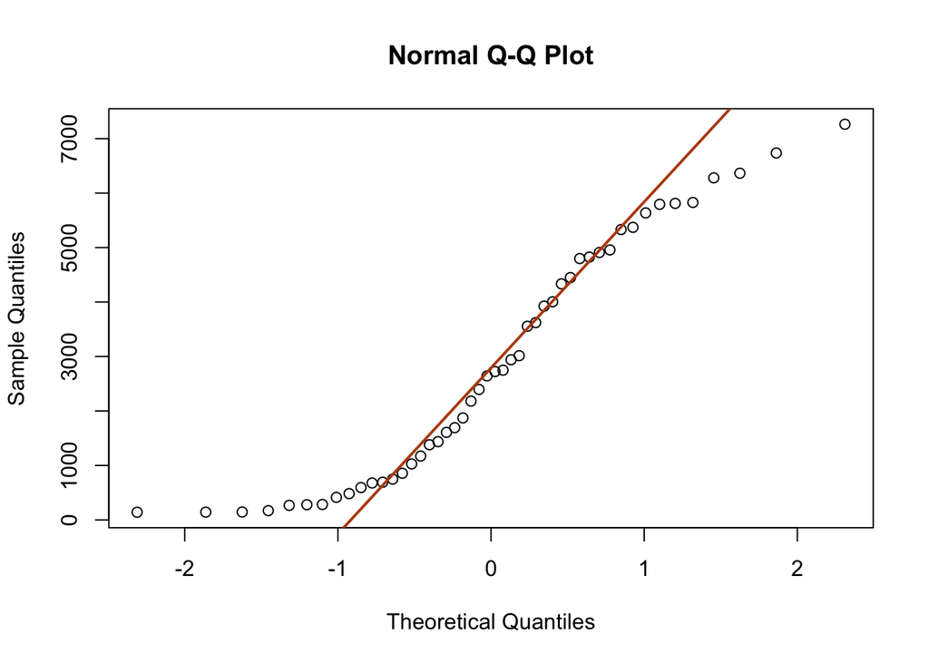

```r
qqnorm(hourly_transfers$total_transfers[hourly_transfers$day_type == "Weekend"])
qqline(hourly_transfers$total_transfers[hourly_transfers$day_type == "Weekend"], col = "#B84A12", lwd = 2)
```

Assumptions check for t-tests:

- Commute vs. Non-commute time
  - Population SD unknown
  - Sample size is large enough (per the CLT) for the test to be robust against normality violations
  - Independent observation assumption may be violated due to time data, but continue with t-test for this class
- Weekday vs. Weekend
  - Population SD unknown
  - Sample size is large enough (per the CLT) for the test to be robust against normality violations
  - Independent observation assumption may be violated due to time data, but continue with t-test for this class

```r
# t-test for commute time vs. non-commute time means
commute_period_test <- t.test(total_transfers ~ commute_period, data = hourly_transfers)
commute_period_test
```

```
##
##  Welch Two Sample t-test
##
## data:  total_transfers by commute_period
## t = 6.5301, df = 61.313, p-value = 1.449e-08
## alternative hypothesis: true difference in means between group Commute and group Non-Commute is not equal to 0
## 95 percent confidence interval:
##  4808.953 9053.408
## sample estimates:
##     mean in group Commute mean in group Non-Commute
##                  9873.127                  2941.947
```

Null hypothesis: Mean hourly ridership of commute periods = Mean hourly ridership of non-commute periods

Alternative hypothesis: Mean hourly ridership of commute periods ≠ Mean hourly ridership of non-commute periods

Alpha = 0.05 > P-value = 1e-08 –> Reject the null hypothesis. There is sufficient evidence to conclude that the mean hourly transfers amounts during commute periods is different that the mean hourly transfers amounts during non-commute

```r
# t-test for weekday vs. weekend means
weekday_weekend_test <- t.test(total_transfers ~ day_type, data = hourly_transfers)
weekday_weekend_test
```

```
##
##  Welch Two Sample t-test
##
## data:  total_transfers by day_type
## t = 4.7669, df = 162.5, p-value = 4.129e-06
## alternative hypothesis: true difference in means between group Weekday and group Weekend is not equal to 0
## 95 percent confidence interval:
##  1906.726 4603.624
## sample estimates:
## mean in group Weekday mean in group Weekend
##              6141.133              2885.958
```

Null hypothesis: Mean hourly ridership of Weekdays = Mean hourly ridership of weekends

Alternative hypothesis: Mean hourly ridership of Weekdays ≠ Mean hourly ridership of weekends

Alpha = 0.05 > P-value = 4e-06 –> Reject the null hypothesis. There is sufficient evidence to conclude that the mean hourly ridership on weekdays is different that the mean hourly ridership of weekends